# Risk Factor Analysis

## Outcome Variable

**Outcome Variable:** whz

## Predictor Variables

**Intervention Variable:** mbmi

**Adjustment Set:**

- arm
- W_mage
- meducyrs
- feducyrs
- hhwealth_quart
- W_nrooms
- brthmon
- W_parity
- impfloor
- impsan
- safeh20
- delta_W_mage
- delta_meducyrs
- delta_feducyrs
- delta_hhwealth_quart
- delta_W_nrooms
- delta_brthmon
- delta_W_parity
- delta_impfloor
- delta_impsan
- delta_safeh20

## Stratifying Variables

The analysis was stratified on these variable(s):

- agecat
- studyid
- country

## Data Summary

| agecat | studyid | country | mbmi | n_cell | n |
| --- | --- | --- | --- | --- | --- |
| Birth | ki0047075b-MAL-ED | BANGLADESH | Normal weight | 183 | 209 |
| Birth | ki0047075b-MAL-ED | BANGLADESH | Underweight | 26 | 209 |
| Birth | ki0047075b-MAL-ED | BRAZIL | Normal weight | 56 | 61 |
| Birth | ki0047075b-MAL-ED | BRAZIL | Underweight | 5 | 61 |
| Birth | ki0047075b-MAL-ED | INDIA | Normal weight | 33 | 41 |
| Birth | ki0047075b-MAL-ED | INDIA | Underweight | 8 | 41 |
| Birth | ki0047075b-MAL-ED | NEPAL | Normal weight | 26 | 26 |
| Birth | ki0047075b-MAL-ED | NEPAL | Underweight | 0 | 26 |
| Birth | ki0047075b-MAL-ED | PERU | Normal weight | 216 | 221 |
| Birth | ki0047075b-MAL-ED | PERU | Underweight | 5 | 221 |
| Birth | ki0047075b-MAL-ED | SOUTH AFRICA | Normal weight | 97 | 100 |
| Birth | ki0047075b-MAL-ED | SOUTH AFRICA | Underweight | 3 | 100 |
| Birth | ki0047075b-MAL-ED | TANZANIA, UNITED REPUBLIC OF | Normal weight | 107 | 113 |
| Birth | ki0047075b-MAL-ED | TANZANIA, UNITED REPUBLIC OF | Underweight | 6 | 113 |
| Birth | ki1000304b-SAS-CompFeed | INDIA | Normal weight | 735 | 992 |
| Birth | ki1000304b-SAS-CompFeed | INDIA | Underweight | 257 | 992 |
| Birth | ki1017093-NIH-Birth | BANGLADESH | Normal weight | 483 | 575 |
| Birth | ki1017093-NIH-Birth | BANGLADESH | Underweight | 92 | 575 |
| Birth | ki1017093b-PROVIDE | BANGLADESH | Normal weight | 411 | 510 |
| Birth | ki1017093b-PROVIDE | BANGLADESH | Underweight | 99 | 510 |
| Birth | ki1017093c-NIH-Crypto | BANGLADESH | Normal weight | 639 | 704 |
| Birth | ki1017093c-NIH-Crypto | BANGLADESH | Underweight | 65 | 704 |
| Birth | ki1119695-PROBIT | BELARUS | Normal weight | 13143 | 13664 |
| Birth | ki1119695-PROBIT | BELARUS | Underweight | 521 | 13664 |
| Birth | ki1126311-ZVITAMBO | ZIMBABWE | Normal weight | 8574 | 9030 |
| Birth | ki1126311-ZVITAMBO | ZIMBABWE | Underweight | 456 | 9030 |
| Birth | kiGH5241-JiVitA-3 | BANGLADESH | Normal weight | 13482 | 21985 |
| Birth | kiGH5241-JiVitA-3 | BANGLADESH | Underweight | 8503 | 21985 |
| 6 months | ki0047075b-MAL-ED | BANGLADESH | Normal weight | 209 | 241 |
| 6 months | ki0047075b-MAL-ED | BANGLADESH | Underweight | 32 | 241 |

[output cut: 60 more lines]

The following strata were considered:

- agecat: 24 months, studyid: ki0047075b-MAL-ED, country: BANGLADESH
- agecat: 24 months, studyid: ki0047075b-MAL-ED, country: BRAZIL
- agecat: 24 months, studyid: ki0047075b-MAL-ED, country: INDIA
- agecat: 24 months, studyid: ki0047075b-MAL-ED, country: NEPAL
- agecat: 24 months, studyid: ki0047075b-MAL-ED, country: PERU
- agecat: 24 months, studyid: ki0047075b-MAL-ED, country: SOUTH AFRICA
- agecat: 24 months, studyid: ki0047075b-MAL-ED, country: TANZANIA, UNITED REPUBLIC OF
- agecat: 24 months, studyid: ki1017093-NIH-Birth, country: BANGLADESH
- agecat: 24 months, studyid: ki1017093b-PROVIDE, country: BANGLADESH
- agecat: 24 months, studyid: ki1017093c-NIH-Crypto, country: BANGLADESH
- agecat: 24 months, studyid: ki1066203-TanzaniaChild2, country: TANZANIA, UNITED REPUBLIC OF
- agecat: 24 months, studyid: ki1119695-PROBIT, country: BELARUS
- agecat: 24 months, studyid: ki1126311-ZVITAMBO, country: ZIMBABWE
- agecat: 24 months, studyid: ki1148112-LCNI-5, country: MALAWI
- agecat: 24 months, studyid: kiGH5241-JiVitA-3, country: BANGLADESH
- agecat: 6 months, studyid: ki0047075b-MAL-ED, country: BANGLADESH
- agecat: 6 months, studyid: ki0047075b-MAL-ED, country: BRAZIL
- agecat: 6 months, studyid: ki0047075b-MAL-ED, country: INDIA
- agecat: 6 months, studyid: ki0047075b-MAL-ED, country: NEPAL
- agecat: 6 months, studyid: ki0047075b-MAL-ED, country: PERU
- agecat: 6 months, studyid: ki0047075b-MAL-ED, country: SOUTH AFRICA
- agecat: 6 months, studyid: ki0047075b-MAL-ED, country: TANZANIA, UNITED REPUBLIC OF
- agecat: 6 months, studyid: ki1000304b-SAS-CompFeed, country: INDIA
- agecat: 6 months, studyid: ki1017093-NIH-Birth, country: BANGLADESH
- agecat: 6 months, studyid: ki1017093b-PROVIDE, country: BANGLADESH
- agecat: 6 months, studyid: ki1017093c-NIH-Crypto, country: BANGLADESH
- agecat: 6 months, studyid: ki1066203-TanzaniaChild2, country: TANZANIA, UNITED REPUBLIC OF
- agecat: 6 months, studyid: ki1119695-PROBIT, country: BELARUS
- agecat: 6 months, studyid: ki1126311-ZVITAMBO, country: ZIMBABWE
- agecat: 6 months, studyid: ki1148112-LCNI-5, country: MALAWI
- agecat: 6 months, studyid: kiGH5241-JiVitA-3, country: BANGLADESH
- agecat: Birth, studyid: ki0047075b-MAL-ED, country: BANGLADESH
- agecat: Birth, studyid: ki0047075b-MAL-ED, country: BRAZIL
- agecat: Birth, studyid: ki0047075b-MAL-ED, country: INDIA
- agecat: Birth, studyid: ki0047075b-MAL-ED, country: NEPAL
- agecat: Birth, studyid: ki0047075b-MAL-ED, country: PERU
- agecat: Birth, studyid: ki0047075b-MAL-ED, country: SOUTH AFRICA
- agecat: Birth, studyid: ki0047075b-MAL-ED, country: TANZANIA, UNITED REPUBLIC OF
- agecat: Birth, studyid: ki1000304b-SAS-CompFeed, country: INDIA
- agecat: Birth, studyid: ki1017093-NIH-Birth, country: BANGLADESH
- agecat: Birth, studyid: ki1017093b-PROVIDE, country: BANGLADESH
- agecat: Birth, studyid: ki1017093c-NIH-Crypto, country: BANGLADESH
- agecat: Birth, studyid: ki1119695-PROBIT, country: BELARUS
- agecat: Birth, studyid: ki1126311-ZVITAMBO, country: ZIMBABWE
- agecat: Birth, studyid: kiGH5241-JiVitA-3, country: BANGLADESH

### Dropped Strata

Some strata were dropped due to rare outcomes:

- agecat: Birth, studyid: ki0047075b-MAL-ED, country: NEPAL
- agecat: Birth, studyid: ki0047075b-MAL-ED, country: SOUTH AFRICA
- agecat: 6 months, studyid: ki0047075b-MAL-ED, country: NEPAL
- agecat: 24 months, studyid: ki0047075b-MAL-ED, country: NEPAL
- agecat: 24 months, studyid: ki0047075b-MAL-ED, country: PERU
- agecat: 24 months, studyid: ki1066203-TanzaniaChild2, country: TANZANIA, UNITED REPUBLIC OF

## Methods Detail

We’re interested in the causal parameters $E[Y_a]$ for all values of $a \in \mathcal{A}$. These parameters represent the mean outcome if, possibly contrary to fact, we intervened to set all units to have $A=a$. Under the randomization and positivity assumptions, these are identified by the statistical parameters $\psi_a=E_W[E_{Y|A,W}(Y|A=a,W)]$. In addition, we’re interested in the mean of $Y$, $E[Y]$ under no intervention (the observed mean). We will estimate these parameters by using SuperLearner to fit the relevant likelihood factors – $E_{Y|A,W}(Y|A=a,W)$ and $p(A=a|W)$, and then updating our likelihood fit using a joint TMLE.

For unadjusted analyses ($W=\{\}$), initial likelihoods were estimated using Lrnr_glm to estimate the simple $E(Y|A)$ and Lrnr_mean to estimate $p(A)$. For adjusted analyses, a small library containing Lrnr_glmnet, Lrnr_xgboost, and Lrnr_mean was used.

Having estimated these parameters, we will then use the delta method to estimate relative risks and attributable risks relative to a prespecified baseline level of $A$.

# Results Detail

## Results Plots

[figure not shown]

[figure not shown]

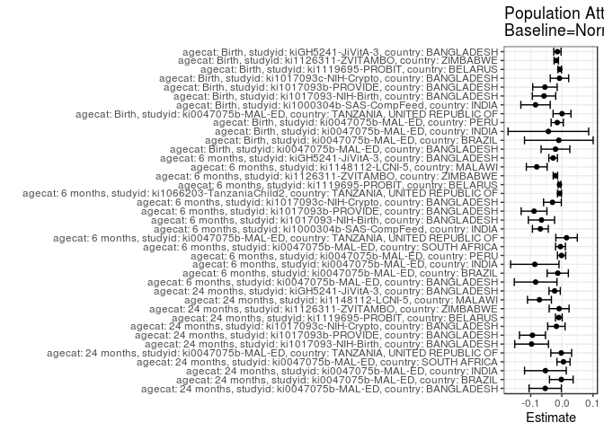

## Results Table

### Parameter: TSM

| agecat | studyid | country | intervention_level | baseline_level | estimate | ci_lower | ci_upper |
| --- | --- | --- | --- | --- | --- | --- | --- |
| Birth | ki0047075b-MAL-ED | BANGLADESH | Normal weight | NA | -0.9323103 | -1.0917849 | -0.7728357 |
| Birth | ki0047075b-MAL-ED | BANGLADESH | Underweight | NA | -1.1007451 | -1.4302972 | -0.7711929 |
| Birth | ki0047075b-MAL-ED | BRAZIL | Normal weight | NA | 0.4114286 | 0.0848121 | 0.7380451 |
| Birth | ki0047075b-MAL-ED | BRAZIL | Underweight | NA | 0.2940000 | -1.0086888 | 1.5966888 |
| Birth | ki0047075b-MAL-ED | INDIA | Normal weight | NA | -0.9245455 | -1.2487999 | -0.6002910 |
| Birth | ki0047075b-MAL-ED | INDIA | Underweight | NA | -1.1462500 | -1.7084286 | -0.5840714 |
| Birth | ki0047075b-MAL-ED | PERU | Normal weight | NA | -0.0281944 | -0.1526241 | 0.0962352 |
| Birth | ki0047075b-MAL-ED | PERU | Underweight | NA | -0.6820000 | -1.2614133 | -0.1025867 |
| Birth | ki0047075b-MAL-ED | TANZANIA, UNITED REPUBLIC OF | Normal weight | NA | 0.7576636 | 0.5539948 | 0.9613323 |
| Birth | ki0047075b-MAL-ED | TANZANIA, UNITED REPUBLIC OF | Underweight | NA | 0.7700000 | 0.2691531 | 1.2708469 |
| Birth | ki1000304b-SAS-CompFeed | INDIA | Normal weight | NA | -0.5907090 | -0.7636544 | -0.4177637 |
| Birth | ki1000304b-SAS-CompFeed | INDIA | Underweight | NA | -0.9136040 | -1.1342989 | -0.6929090 |
| Birth | ki1017093-NIH-Birth | BANGLADESH | Normal weight | NA | -1.2927063 | -1.3975031 | -1.1879094 |
| Birth | ki1017093-NIH-Birth | BANGLADESH | Underweight | NA | -1.6777343 | -1.8857254 | -1.4697431 |
| Birth | ki1017093b-PROVIDE | BANGLADESH | Normal weight | NA | -1.2517696 | -1.3387545 | -1.1647848 |
| Birth | ki1017093b-PROVIDE | BANGLADESH | Underweight | NA | -1.5276957 | -1.7260267 | -1.3293647 |
| Birth | ki1017093c-NIH-Crypto | BANGLADESH | Normal weight | NA | -1.2358313 | -1.3246427 | -1.1470198 |
| Birth | ki1017093c-NIH-Crypto | BANGLADESH | Underweight | NA | -1.2825520 | -1.6212170 | -0.9438870 |
| Birth | ki1119695-PROBIT | BELARUS | Normal weight | NA | -1.1361525 | -1.3460870 | -0.9262180 |
| Birth | ki1119695-PROBIT | BELARUS | Underweight | NA | -1.3185810 | -1.5749593 | -1.0622026 |
| Birth | ki1126311-ZVITAMBO | ZIMBABWE | Normal weight | NA | -0.4726297 | -0.5043903 | -0.4408690 |
| Birth | ki1126311-ZVITAMBO | ZIMBABWE | Underweight | NA | -0.8350278 | -0.9739748 | -0.6960809 |
| Birth | kiGH5241-JiVitA-3 | BANGLADESH | Normal weight | NA | -0.7362917 | -0.7580781 | -0.7145052 |
| Birth | kiGH5241-JiVitA-3 | BANGLADESH | Underweight | NA | -0.7728779 | -0.7981116 | -0.7476442 |
| 6 months | ki0047075b-MAL-ED | BANGLADESH | Normal weight | NA | -0.0541261 | -0.1834143 | 0.0751622 |
| 6 months | ki0047075b-MAL-ED | BANGLADESH | Underweight | NA | -0.7310663 | -1.2119375 | -0.2501952 |
| 6 months | ki0047075b-MAL-ED | BRAZIL | Normal weight | NA | 0.9775209 | 0.8091090 | 1.1459329 |
| 6 months | ki0047075b-MAL-ED | BRAZIL | Underweight | NA | 0.6764815 | -0.0674862 | 1.4204491 |
| 6 months | ki0047075b-MAL-ED | INDIA | Normal weight | NA | -0.6168069 | -0.7491775 | -0.4844363 |
| 6 months | ki0047075b-MAL-ED | INDIA | Underweight | NA | -1.0340314 | -1.3805081 | -0.6875546 |
| 6 months | ki0047075b-MAL-ED | PERU | Normal weight | NA | 1.0597503 | 0.9353314 | 1.1841693 |
| 6 months | ki0047075b-MAL-ED | PERU | Underweight | NA | 1.0130000 | 0.5008674 | 1.5251326 |
| 6 months | ki0047075b-MAL-ED | SOUTH AFRICA | Normal weight | NA | 0.5340771 | 0.3764293 | 0.6917250 |
| 6 months | ki0047075b-MAL-ED | SOUTH AFRICA | Underweight | NA | 0.3785714 | -0.1478585 | 0.9050014 |
| 6 months | ki0047075b-MAL-ED | TANZANIA, UNITED REPUBLIC OF | Normal weight | NA | 0.5210139 | 0.3857888 | 0.6562390 |
| 6 months | ki0047075b-MAL-ED | TANZANIA, UNITED REPUBLIC OF | Underweight | NA | 0.4703328 | -0.2172105 | 1.1578761 |
| 6 months | ki1000304b-SAS-CompFeed | INDIA | Normal weight | NA | -0.5735856 | -0.7078940 | -0.4392772 |
| 6 months | ki1000304b-SAS-CompFeed | INDIA | Underweight | NA | -0.8349899 | -0.9678920 | -0.7020879 |
| 6 months | ki1017093-NIH-Birth | BANGLADESH | Normal weight | NA | -0.3819912 | -0.4813557 | -0.2826266 |
| 6 months | ki1017093-NIH-Birth | BANGLADESH | Underweight | NA | -0.7696346 | -0.9813285 | -0.5579407 |
| 6 months | ki1017093b-PROVIDE | BANGLADESH | Normal weight | NA | -0.1093973 | -0.1997076 | -0.0190869 |
| 6 months | ki1017093b-PROVIDE | BANGLADESH | Underweight | NA | -0.6686471 | -0.8943008 | -0.4429934 |
| 6 months | ki1017093c-NIH-Crypto | BANGLADESH | Normal weight | NA | 0.0599172 | -0.0219173 | 0.1417518 |
| 6 months | ki1017093c-NIH-Crypto | BANGLADESH | Underweight | NA | -0.3856470 | -0.7327009 | -0.0385932 |
| 6 months | ki1066203-TanzaniaChild2 | TANZANIA, UNITED REPUBLIC OF | Normal weight | NA | 0.0850182 | 0.0305256 | 0.1395108 |
| 6 months | ki1066203-TanzaniaChild2 | TANZANIA, UNITED REPUBLIC OF | Underweight | NA | -0.3646496 | -0.5928291 | -0.1364701 |
| 6 months | ki1119695-PROBIT | BELARUS | Normal weight | NA | 0.5904541 | 0.5327971 | 0.6481112 |
| 6 months | ki1119695-PROBIT | BELARUS | Underweight | NA | 0.3941993 | 0.2694252 | 0.5189734 |
| 6 months | ki1126311-ZVITAMBO | ZIMBABWE | Normal weight | NA | 0.3155612 | 0.2873986 | 0.3437238 |
| 6 months | ki1126311-ZVITAMBO | ZIMBABWE | Underweight | NA | -0.1322979 | -0.2709509 | 0.0063551 |
| 6 months | ki1148112-LCNI-5 | MALAWI | Normal weight | NA | 0.5321670 | 0.4538377 | 0.6104964 |
| 6 months | ki1148112-LCNI-5 | MALAWI | Underweight | NA | 0.0794100 | -0.0897009 | 0.2485209 |
| 6 months | kiGH5241-JiVitA-3 | BANGLADESH | Normal weight | NA | -0.5646792 | -0.5877728 | -0.5415857 |
| 6 months | kiGH5241-JiVitA-3 | BANGLADESH | Underweight | NA | -0.6375620 | -0.6684144 | -0.6067095 |
| 24 months | ki0047075b-MAL-ED | BANGLADESH | Normal weight | NA | -0.7667869 | -0.8981571 | -0.6354166 |
| 24 months | ki0047075b-MAL-ED | BANGLADESH | Underweight | NA | -1.1498949 | -1.4757901 | -0.8239997 |
| 24 months | ki0047075b-MAL-ED | BRAZIL | Normal weight | NA | 0.4425926 | 0.2340990 | 0.6510862 |
| 24 months | ki0047075b-MAL-ED | BRAZIL | Underweight | NA | 0.3966667 | -0.6451983 | 1.4385316 |
| 24 months | ki0047075b-MAL-ED | INDIA | Normal weight | NA | -0.8997817 | -1.0237568 | -0.7758067 |
| 24 months | ki0047075b-MAL-ED | INDIA | Underweight | NA | -1.1902769 | -1.4803568 | -0.9001970 |
| 24 months | ki0047075b-MAL-ED | SOUTH AFRICA | Normal weight | NA | 0.3922467 | 0.2694589 | 0.5150345 |
| 24 months | ki0047075b-MAL-ED | SOUTH AFRICA | Underweight | NA | 0.5700000 | -0.1123856 | 1.2523856 |
| 24 months | ki0047075b-MAL-ED | TANZANIA, UNITED REPUBLIC OF | Normal weight | NA | 0.0559141 | -0.0714136 | 0.1832417 |
| 24 months | ki0047075b-MAL-ED | TANZANIA, UNITED REPUBLIC OF | Underweight | NA | 0.0491608 | -0.7771985 | 0.8755201 |
| 24 months | ki1017093-NIH-Birth | BANGLADESH | Normal weight | NA | -0.8144601 | -0.9178239 | -0.7110963 |
| 24 months | ki1017093-NIH-Birth | BANGLADESH | Underweight | NA | -1.3161859 | -1.5703009 | -1.0620709 |
| 24 months | ki1017093b-PROVIDE | BANGLADESH | Normal weight | NA | -0.7970457 | -0.8874391 | -0.7066522 |
| 24 months | ki1017093b-PROVIDE | BANGLADESH | Underweight | NA | -1.3961397 | -1.6296443 | -1.1626350 |
| 24 months | ki1017093c-NIH-Crypto | BANGLADESH | Normal weight | NA | -0.5928558 | -0.6919871 | -0.4937244 |
| 24 months | ki1017093c-NIH-Crypto | BANGLADESH | Underweight | NA | -0.9370528 | -1.2645242 | -0.6095814 |
| 24 months | ki1119695-PROBIT | BELARUS | Normal weight | NA | 0.6977058 | 0.5873128 | 0.8080988 |
| 24 months | ki1119695-PROBIT | BELARUS | Underweight | NA | 0.4037207 | -0.0010227 | 0.8084641 |
| 24 months | ki1126311-ZVITAMBO | ZIMBABWE | Normal weight | NA | -1.1631118 | -1.2765248 | -1.0496988 |
| 24 months | ki1126311-ZVITAMBO | ZIMBABWE | Underweight | NA | -1.2130462 | -1.6668468 | -0.7592456 |
| 24 months | ki1148112-LCNI-5 | MALAWI | Normal weight | NA | 0.0250704 | -0.0650486 | 0.1151895 |
| 24 months | ki1148112-LCNI-5 | MALAWI | Underweight | NA | -0.3935970 | -0.5851024 | -0.2020917 |
| 24 months | kiGH5241-JiVitA-3 | BANGLADESH | Normal weight | NA | -1.2756432 | -1.3053188 | -1.2459676 |
| 24 months | kiGH5241-JiVitA-3 | BANGLADESH | Underweight | NA | -1.3369929 | -1.3740581 | -1.2999277 |

### Parameter: E(Y)

| agecat | studyid | country | intervention_level | baseline_level | estimate | ci_lower | ci_upper |
| --- | --- | --- | --- | --- | --- | --- | --- |
| Birth | ki0047075b-MAL-ED | BANGLADESH | NA | NA | -0.9526794 | -1.0978709 | -0.8074880 |
| Birth | ki0047075b-MAL-ED | BRAZIL | NA | NA | 0.4018033 | 0.0834093 | 0.7201973 |
| Birth | ki0047075b-MAL-ED | INDIA | NA | NA | -0.9678049 | -1.2522118 | -0.6833979 |
| Birth | ki0047075b-MAL-ED | PERU | NA | NA | -0.0429864 | -0.1658406 | 0.0798678 |
| Birth | ki0047075b-MAL-ED | TANZANIA, UNITED REPUBLIC OF | NA | NA | 0.7583186 | 0.5636385 | 0.9529987 |
| Birth | ki1000304b-SAS-CompFeed | INDIA | NA | NA | -0.6752218 | -0.8548888 | -0.4955547 |
| Birth | ki1017093-NIH-Birth | BANGLADESH | NA | NA | -1.3499217 | -1.4444634 | -1.2553801 |
| Birth | ki1017093b-PROVIDE | BANGLADESH | NA | NA | -1.3060980 | -1.3843247 | -1.2278714 |
| Birth | ki1017093c-NIH-Crypto | BANGLADESH | NA | NA | -1.2434730 | -1.3276901 | -1.1592559 |
| Birth | ki1119695-PROBIT | BELARUS | NA | NA | -1.1429259 | -1.3532676 | -0.9325843 |
| Birth | ki1126311-ZVITAMBO | ZIMBABWE | NA | NA | -0.4905338 | -0.5214551 | -0.4596125 |
| Birth | kiGH5241-JiVitA-3 | BANGLADESH | NA | NA | -0.7505381 | -0.7684193 | -0.7326569 |
| 6 months | ki0047075b-MAL-ED | BANGLADESH | NA | NA | -0.1383956 | -0.2672708 | -0.0095204 |
| 6 months | ki0047075b-MAL-ED | BRAZIL | NA | NA | 0.9644952 | 0.7999744 | 1.1290160 |
| 6 months | ki0047075b-MAL-ED | INDIA | NA | NA | -0.7036879 | -0.8303672 | -0.5770087 |
| 6 months | ki0047075b-MAL-ED | PERU | NA | NA | 1.0588909 | 0.9369064 | 1.1808755 |
| 6 months | ki0047075b-MAL-ED | SOUTH AFRICA | NA | NA | 0.5297055 | 0.3757432 | 0.6836678 |
| 6 months | ki0047075b-MAL-ED | TANZANIA, UNITED REPUBLIC OF | NA | NA | 0.5362213 | 0.4049390 | 0.6675036 |
| 6 months | ki1000304b-SAS-CompFeed | INDIA | NA | NA | -0.6426305 | -0.7702214 | -0.5150396 |
| 6 months | ki1017093-NIH-Birth | BANGLADESH | NA | NA | -0.4474038 | -0.5378167 | -0.3569909 |
| 6 months | ki1017093b-PROVIDE | BANGLADESH | NA | NA | -0.1987071 | -0.2815473 | -0.1158669 |
| 6 months | ki1017093c-NIH-Crypto | BANGLADESH | NA | NA | 0.0297622 | -0.0491685 | 0.1086930 |
| 6 months | ki1066203-TanzaniaChild2 | TANZANIA, UNITED REPUBLIC OF | NA | NA | 0.0775172 | 0.0241750 | 0.1308595 |
| 6 months | ki1119695-PROBIT | BELARUS | NA | NA | 0.5829956 | 0.5247249 | 0.6412663 |
| 6 months | ki1126311-ZVITAMBO | ZIMBABWE | NA | NA | 0.2948332 | 0.2672524 | 0.3224139 |
| 6 months | ki1148112-LCNI-5 | MALAWI | NA | NA | 0.4515550 | 0.3802638 | 0.5228463 |
| 6 months | kiGH5241-JiVitA-3 | BANGLADESH | NA | NA | -0.5926564 | -0.6122365 | -0.5730762 |
| 24 months | ki0047075b-MAL-ED | BANGLADESH | NA | NA | -0.8201887 | -0.9423967 | -0.6979806 |
| 24 months | ki0047075b-MAL-ED | BRAZIL | NA | NA | 0.4409524 | 0.2364865 | 0.6454182 |
| 24 months | ki0047075b-MAL-ED | INDIA | NA | NA | -0.9525664 | -1.0684455 | -0.8366872 |
| 24 months | ki0047075b-MAL-ED | SOUTH AFRICA | NA | NA | 0.3975641 | 0.2766504 | 0.5184778 |
| 24 months | ki0047075b-MAL-ED | TANZANIA, UNITED REPUBLIC OF | NA | NA | 0.0539486 | -0.0712465 | 0.1791437 |
| 24 months | ki1017093-NIH-Birth | BANGLADESH | NA | NA | -0.9115790 | -1.0095022 | -0.8136559 |
| 24 months | ki1017093b-PROVIDE | BANGLADESH | NA | NA | -0.8914360 | -0.9741797 | -0.8086923 |
| 24 months | ki1017093c-NIH-Crypto | BANGLADESH | NA | NA | -0.6103502 | -0.7050157 | -0.5156847 |
| 24 months | ki1119695-PROBIT | BELARUS | NA | NA | 0.6880695 | 0.5737062 | 0.8024328 |
| 24 months | ki1126311-ZVITAMBO | ZIMBABWE | NA | NA | -1.1718579 | -1.2809898 | -1.0627260 |
| 24 months | ki1148112-LCNI-5 | MALAWI | NA | NA | -0.0468717 | -0.1290135 | 0.0352701 |
| 24 months | kiGH5241-JiVitA-3 | BANGLADESH | NA | NA | -1.2986831 | -1.3220580 | -1.2753083 |

### Parameter: ATE

| agecat | studyid | country | intervention_level | baseline_level | estimate | ci_lower | ci_upper |
| --- | --- | --- | --- | --- | --- | --- | --- |
| Birth | ki0047075b-MAL-ED | BANGLADESH | Normal weight | Normal weight | 0.0000000 | 0.0000000 | 0.0000000 |
| Birth | ki0047075b-MAL-ED | BANGLADESH | Underweight | Normal weight | -0.1684347 | -0.5349431 | 0.1980736 |
| Birth | ki0047075b-MAL-ED | BRAZIL | Normal weight | Normal weight | 0.0000000 | 0.0000000 | 0.0000000 |
| Birth | ki0047075b-MAL-ED | BRAZIL | Underweight | Normal weight | -0.1174286 | -1.4604388 | 1.2255816 |
| Birth | ki0047075b-MAL-ED | INDIA | Normal weight | Normal weight | 0.0000000 | 0.0000000 | 0.0000000 |
| Birth | ki0047075b-MAL-ED | INDIA | Underweight | Normal weight | -0.2217045 | -0.8706928 | 0.4272837 |
| Birth | ki0047075b-MAL-ED | PERU | Normal weight | Normal weight | 0.0000000 | 0.0000000 | 0.0000000 |
| Birth | ki0047075b-MAL-ED | PERU | Underweight | Normal weight | -0.6538056 | -1.2464290 | -0.0611821 |
| Birth | ki0047075b-MAL-ED | TANZANIA, UNITED REPUBLIC OF | Normal weight | Normal weight | 0.0000000 | 0.0000000 | 0.0000000 |
| Birth | ki0047075b-MAL-ED | TANZANIA, UNITED REPUBLIC OF | Underweight | Normal weight | 0.0123364 | -0.5283378 | 0.5530107 |
| Birth | ki1000304b-SAS-CompFeed | INDIA | Normal weight | Normal weight | 0.0000000 | 0.0000000 | 0.0000000 |
| Birth | ki1000304b-SAS-CompFeed | INDIA | Underweight | Normal weight | -0.3228949 | -0.4941872 | -0.1516026 |
| Birth | ki1017093-NIH-Birth | BANGLADESH | Normal weight | Normal weight | 0.0000000 | 0.0000000 | 0.0000000 |
| Birth | ki1017093-NIH-Birth | BANGLADESH | Underweight | Normal weight | -0.3850280 | -0.6170053 | -0.1530507 |
| Birth | ki1017093b-PROVIDE | BANGLADESH | Normal weight | Normal weight | 0.0000000 | 0.0000000 | 0.0000000 |
| Birth | ki1017093b-PROVIDE | BANGLADESH | Underweight | Normal weight | -0.2759261 | -0.4927640 | -0.0590881 |
| Birth | ki1017093c-NIH-Crypto | BANGLADESH | Normal weight | Normal weight | 0.0000000 | 0.0000000 | 0.0000000 |
| Birth | ki1017093c-NIH-Crypto | BANGLADESH | Underweight | Normal weight | -0.0467207 | -0.3974955 | 0.3040540 |
| Birth | ki1119695-PROBIT | BELARUS | Normal weight | Normal weight | 0.0000000 | 0.0000000 | 0.0000000 |
| Birth | ki1119695-PROBIT | BELARUS | Underweight | Normal weight | -0.1824284 | -0.3261647 | -0.0386922 |
| Birth | ki1126311-ZVITAMBO | ZIMBABWE | Normal weight | Normal weight | 0.0000000 | 0.0000000 | 0.0000000 |
| Birth | ki1126311-ZVITAMBO | ZIMBABWE | Underweight | Normal weight | -0.3623982 | -0.5049581 | -0.2198383 |
| Birth | kiGH5241-JiVitA-3 | BANGLADESH | Normal weight | Normal weight | 0.0000000 | 0.0000000 | 0.0000000 |
| Birth | kiGH5241-JiVitA-3 | BANGLADESH | Underweight | Normal weight | -0.0365862 | -0.0667762 | -0.0063963 |
| 6 months | ki0047075b-MAL-ED | BANGLADESH | Normal weight | Normal weight | 0.0000000 | 0.0000000 | 0.0000000 |
| 6 months | ki0047075b-MAL-ED | BANGLADESH | Underweight | Normal weight | -0.6769402 | -1.1751382 | -0.1787422 |
| 6 months | ki0047075b-MAL-ED | BRAZIL | Normal weight | Normal weight | 0.0000000 | 0.0000000 | 0.0000000 |
| 6 months | ki0047075b-MAL-ED | BRAZIL | Underweight | Normal weight | -0.3010395 | -1.0638307 | 0.4617517 |
| 6 months | ki0047075b-MAL-ED | INDIA | Normal weight | Normal weight | 0.0000000 | 0.0000000 | 0.0000000 |
| 6 months | ki0047075b-MAL-ED | INDIA | Underweight | Normal weight | -0.4172245 | -0.7886941 | -0.0457549 |
| 6 months | ki0047075b-MAL-ED | PERU | Normal weight | Normal weight | 0.0000000 | 0.0000000 | 0.0000000 |
| 6 months | ki0047075b-MAL-ED | PERU | Underweight | Normal weight | -0.0467503 | -0.5737796 | 0.4802790 |
| 6 months | ki0047075b-MAL-ED | SOUTH AFRICA | Normal weight | Normal weight | 0.0000000 | 0.0000000 | 0.0000000 |
| 6 months | ki0047075b-MAL-ED | SOUTH AFRICA | Underweight | Normal weight | -0.1555057 | -0.7050340 | 0.3940226 |
| 6 months | ki0047075b-MAL-ED | TANZANIA, UNITED REPUBLIC OF | Normal weight | Normal weight | 0.0000000 | 0.0000000 | 0.0000000 |
| 6 months | ki0047075b-MAL-ED | TANZANIA, UNITED REPUBLIC OF | Underweight | Normal weight | -0.0506811 | -0.7550549 | 0.6536927 |
| 6 months | ki1000304b-SAS-CompFeed | INDIA | Normal weight | Normal weight | 0.0000000 | 0.0000000 | 0.0000000 |
| 6 months | ki1000304b-SAS-CompFeed | INDIA | Underweight | Normal weight | -0.2614043 | -0.3637852 | -0.1590234 |
| 6 months | ki1017093-NIH-Birth | BANGLADESH | Normal weight | Normal weight | 0.0000000 | 0.0000000 | 0.0000000 |
| 6 months | ki1017093-NIH-Birth | BANGLADESH | Underweight | Normal weight | -0.3876435 | -0.6218235 | -0.1534634 |
| 6 months | ki1017093b-PROVIDE | BANGLADESH | Normal weight | Normal weight | 0.0000000 | 0.0000000 | 0.0000000 |
| 6 months | ki1017093b-PROVIDE | BANGLADESH | Underweight | Normal weight | -0.5592498 | -0.8022008 | -0.3162988 |
| 6 months | ki1017093c-NIH-Crypto | BANGLADESH | Normal weight | Normal weight | 0.0000000 | 0.0000000 | 0.0000000 |
| 6 months | ki1017093c-NIH-Crypto | BANGLADESH | Underweight | Normal weight | -0.4455643 | -0.8021854 | -0.0889432 |
| 6 months | ki1066203-TanzaniaChild2 | TANZANIA, UNITED REPUBLIC OF | Normal weight | Normal weight | 0.0000000 | 0.0000000 | 0.0000000 |
| 6 months | ki1066203-TanzaniaChild2 | TANZANIA, UNITED REPUBLIC OF | Underweight | Normal weight | -0.4496678 | -0.6841663 | -0.2151693 |
| 6 months | ki1119695-PROBIT | BELARUS | Normal weight | Normal weight | 0.0000000 | 0.0000000 | 0.0000000 |
| 6 months | ki1119695-PROBIT | BELARUS | Underweight | Normal weight | -0.1962548 | -0.3061193 | -0.0863904 |
| 6 months | ki1126311-ZVITAMBO | ZIMBABWE | Normal weight | Normal weight | 0.0000000 | 0.0000000 | 0.0000000 |
| 6 months | ki1126311-ZVITAMBO | ZIMBABWE | Underweight | Normal weight | -0.4478591 | -0.5893173 | -0.3064008 |
| 6 months | ki1148112-LCNI-5 | MALAWI | Normal weight | Normal weight | 0.0000000 | 0.0000000 | 0.0000000 |
| 6 months | ki1148112-LCNI-5 | MALAWI | Underweight | Normal weight | -0.4527571 | -0.6392998 | -0.2662143 |
| 6 months | kiGH5241-JiVitA-3 | BANGLADESH | Normal weight | Normal weight | 0.0000000 | 0.0000000 | 0.0000000 |
| 6 months | kiGH5241-JiVitA-3 | BANGLADESH | Underweight | Normal weight | -0.0728827 | -0.1090390 | -0.0367265 |
| 24 months | ki0047075b-MAL-ED | BANGLADESH | Normal weight | Normal weight | 0.0000000 | 0.0000000 | 0.0000000 |
| 24 months | ki0047075b-MAL-ED | BANGLADESH | Underweight | Normal weight | -0.3831081 | -0.7346712 | -0.0315450 |
| 24 months | ki0047075b-MAL-ED | BRAZIL | Normal weight | Normal weight | 0.0000000 | 0.0000000 | 0.0000000 |
| 24 months | ki0047075b-MAL-ED | BRAZIL | Underweight | Normal weight | -0.0459259 | -1.1084475 | 1.0165957 |
| 24 months | ki0047075b-MAL-ED | INDIA | Normal weight | Normal weight | 0.0000000 | 0.0000000 | 0.0000000 |
| 24 months | ki0047075b-MAL-ED | INDIA | Underweight | Normal weight | -0.2904951 | -0.6067166 | 0.0257264 |
| 24 months | ki0047075b-MAL-ED | SOUTH AFRICA | Normal weight | Normal weight | 0.0000000 | 0.0000000 | 0.0000000 |
| 24 months | ki0047075b-MAL-ED | SOUTH AFRICA | Underweight | Normal weight | 0.1777533 | -0.5155915 | 0.8710981 |
| 24 months | ki0047075b-MAL-ED | TANZANIA, UNITED REPUBLIC OF | Normal weight | Normal weight | 0.0000000 | 0.0000000 | 0.0000000 |
| 24 months | ki0047075b-MAL-ED | TANZANIA, UNITED REPUBLIC OF | Underweight | Normal weight | -0.0067533 | -0.8424444 | 0.8289379 |
| 24 months | ki1017093-NIH-Birth | BANGLADESH | Normal weight | Normal weight | 0.0000000 | 0.0000000 | 0.0000000 |
| 24 months | ki1017093-NIH-Birth | BANGLADESH | Underweight | Normal weight | -0.5017258 | -0.7760336 | -0.2274179 |
| 24 months | ki1017093b-PROVIDE | BANGLADESH | Normal weight | Normal weight | 0.0000000 | 0.0000000 | 0.0000000 |
| 24 months | ki1017093b-PROVIDE | BANGLADESH | Underweight | Normal weight | -0.5990940 | -0.8489912 | -0.3491968 |
| 24 months | ki1017093c-NIH-Crypto | BANGLADESH | Normal weight | Normal weight | 0.0000000 | 0.0000000 | 0.0000000 |
| 24 months | ki1017093c-NIH-Crypto | BANGLADESH | Underweight | Normal weight | -0.3441970 | -0.6861336 | -0.0022604 |
| 24 months | ki1119695-PROBIT | BELARUS | Normal weight | Normal weight | 0.0000000 | 0.0000000 | 0.0000000 |
| 24 months | ki1119695-PROBIT | BELARUS | Underweight | Normal weight | -0.2939851 | -0.6490749 | 0.0611047 |
| 24 months | ki1126311-ZVITAMBO | ZIMBABWE | Normal weight | Normal weight | 0.0000000 | 0.0000000 | 0.0000000 |
| 24 months | ki1126311-ZVITAMBO | ZIMBABWE | Underweight | Normal weight | -0.0499344 | -0.5190451 | 0.4191763 |
| 24 months | ki1148112-LCNI-5 | MALAWI | Normal weight | Normal weight | 0.0000000 | 0.0000000 | 0.0000000 |
| 24 months | ki1148112-LCNI-5 | MALAWI | Underweight | Normal weight | -0.4186674 | -0.6303459 | -0.2069890 |
| 24 months | kiGH5241-JiVitA-3 | BANGLADESH | Normal weight | Normal weight | 0.0000000 | 0.0000000 | 0.0000000 |
| 24 months | kiGH5241-JiVitA-3 | BANGLADESH | Underweight | Normal weight | -0.0613497 | -0.1084890 | -0.0142105 |

### Parameter: PAR

| agecat | studyid | country | intervention_level | baseline_level | estimate | ci_lower | ci_upper |
| --- | --- | --- | --- | --- | --- | --- | --- |
| Birth | ki0047075b-MAL-ED | BANGLADESH | Normal weight | NA | -0.0203691 | -0.0665280 | 0.0257898 |
| Birth | ki0047075b-MAL-ED | BRAZIL | Normal weight | NA | -0.0096253 | -0.1200094 | 0.1007588 |
| Birth | ki0047075b-MAL-ED | INDIA | Normal weight | NA | -0.0432594 | -0.1727854 | 0.0862665 |
| Birth | ki0047075b-MAL-ED | PERU | Normal weight | NA | -0.0147920 | -0.0344019 | 0.0048180 |
| Birth | ki0047075b-MAL-ED | TANZANIA, UNITED REPUBLIC OF | Normal weight | NA | 0.0006550 | -0.0280579 | 0.0293680 |
| Birth | ki1000304b-SAS-CompFeed | INDIA | Normal weight | NA | -0.0845127 | -0.1317662 | -0.0372593 |
| Birth | ki1017093-NIH-Birth | BANGLADESH | Normal weight | NA | -0.0572155 | -0.0947895 | -0.0196415 |
| Birth | ki1017093b-PROVIDE | BANGLADESH | Normal weight | NA | -0.0543284 | -0.0935416 | -0.0151153 |
| Birth | ki1017093c-NIH-Crypto | BANGLADESH | Normal weight | NA | -0.0076418 | -0.0371877 | 0.0219042 |
| Birth | ki1119695-PROBIT | BELARUS | Normal weight | NA | -0.0067734 | -0.0124871 | -0.0010598 |
| Birth | ki1126311-ZVITAMBO | ZIMBABWE | Normal weight | NA | -0.0179041 | -0.0250529 | -0.0107553 |
| Birth | kiGH5241-JiVitA-3 | BANGLADESH | Normal weight | NA | -0.0142464 | -0.0259325 | -0.0025603 |
| 6 months | ki0047075b-MAL-ED | BANGLADESH | Normal weight | NA | -0.0842695 | -0.1528448 | -0.0156942 |
| 6 months | ki0047075b-MAL-ED | BRAZIL | Normal weight | NA | -0.0130257 | -0.0470695 | 0.0210180 |
| 6 months | ki0047075b-MAL-ED | INDIA | Normal weight | NA | -0.0868811 | -0.1646155 | -0.0091467 |
| 6 months | ki0047075b-MAL-ED | PERU | Normal weight | NA | -0.0008594 | -0.0140563 | 0.0123375 |
| 6 months | ki0047075b-MAL-ED | SOUTH AFRICA | Normal weight | NA | -0.0043716 | -0.0201480 | 0.0114047 |
| 6 months | ki0047075b-MAL-ED | TANZANIA, UNITED REPUBLIC OF | Normal weight | NA | 0.0152074 | -0.0193012 | 0.0497161 |
| 6 months | ki1000304b-SAS-CompFeed | INDIA | Normal weight | NA | -0.0690449 | -0.0944764 | -0.0436133 |
| 6 months | ki1017093-NIH-Birth | BANGLADESH | Normal weight | NA | -0.0654126 | -0.1075117 | -0.0233136 |
| 6 months | ki1017093b-PROVIDE | BANGLADESH | Normal weight | NA | -0.0893098 | -0.1307234 | -0.0478962 |
| 6 months | ki1017093c-NIH-Crypto | BANGLADESH | Normal weight | NA | -0.0301550 | -0.0586768 | -0.0016332 |
| 6 months | ki1066203-TanzaniaChild2 | TANZANIA, UNITED REPUBLIC OF | Normal weight | NA | -0.0075010 | -0.0137955 | -0.0012064 |
| 6 months | ki1119695-PROBIT | BELARUS | Normal weight | NA | -0.0074585 | -0.0118265 | -0.0030905 |
| 6 months | ki1126311-ZVITAMBO | ZIMBABWE | Normal weight | NA | -0.0207280 | -0.0278571 | -0.0135989 |
| 6 months | ki1148112-LCNI-5 | MALAWI | Normal weight | NA | -0.0806120 | -0.1140693 | -0.0471547 |
| 6 months | kiGH5241-JiVitA-3 | BANGLADESH | Normal weight | NA | -0.0279771 | -0.0418481 | -0.0141062 |
| 24 months | ki0047075b-MAL-ED | BANGLADESH | Normal weight | NA | -0.0534018 | -0.1054238 | -0.0013798 |
| 24 months | ki0047075b-MAL-ED | BRAZIL | Normal weight | NA | -0.0016402 | -0.0396094 | 0.0363290 |
| 24 months | ki0047075b-MAL-ED | INDIA | Normal weight | NA | -0.0527846 | -0.1198525 | 0.0142833 |
| 24 months | ki0047075b-MAL-ED | SOUTH AFRICA | Normal weight | NA | 0.0053174 | -0.0157850 | 0.0264198 |
| 24 months | ki0047075b-MAL-ED | TANZANIA, UNITED REPUBLIC OF | Normal weight | NA | -0.0019655 | -0.0353869 | 0.0314560 |
| 24 months | ki1017093-NIH-Birth | BANGLADESH | Normal weight | NA | -0.0971189 | -0.1513121 | -0.0429257 |
| 24 months | ki1017093b-PROVIDE | BANGLADESH | Normal weight | NA | -0.0943903 | -0.1361443 | -0.0526362 |
| 24 months | ki1017093c-NIH-Crypto | BANGLADESH | Normal weight | NA | -0.0174944 | -0.0453991 | 0.0104102 |
| 24 months | ki1119695-PROBIT | BELARUS | Normal weight | NA | -0.0096363 | -0.0204007 | 0.0011281 |
| 24 months | ki1126311-ZVITAMBO | ZIMBABWE | Normal weight | NA | -0.0087461 | -0.0407865 | 0.0232943 |
| 24 months | ki1148112-LCNI-5 | MALAWI | Normal weight | NA | -0.0719421 | -0.1103921 | -0.0334920 |
| 24 months | kiGH5241-JiVitA-3 | BANGLADESH | Normal weight | NA | -0.0230400 | -0.0411979 | -0.0048820 |